# Lecture-Lab 1: Course introduction

KNHSM08 / KOMP014: Quantitative Methods in  
Music Education Research 2026

nils.holmberg@iko.lu.se | anna.houmann@mhm.lu.se

## Presentation round

- Nils Holmberg
- Dept. of Communication
- Digital Marketing
- Computational  
  content analysis
- Cognitive  
  communication effects

[video not shown]

## Course design

| Module | Lecture-Lab | Individual work |
| --- | --- | --- |
| Data collection 1 | 1, 2 |  |
| Data analysis 1 | 3, 4 |  |
| Data collection 2 | 5 | 1 |
| Data analysis 2 | 6, 7 | 2 |
| Examination |  |  |

## Course literature (selected)

[figure not shown]

Muijs (2011b); Muijs (2011a)

[figure not shown]

Johnson (2021)

[figure not shown]

McPherson (2005); McPherson and O’Neill (2010b)

## Lecture-Lab 1

- **Module:** Data collection 1
- **Topic:** Research design, theoretical models, test scores, implementing variables
- **Date:** 2026-09-01 at 11—17
- **Place:** MHM
- **Readings:** (Muijs 2011b, chs. 1 and 3–4; Ehninger et al. 2021)

```
graph LR
    direction LR

    subgraph Analysis [<b>Effects on penguin body mass</b>]
        direction LR

        %% Independent Variables
        iv1(bill_length_mm)
        iv2(species)
        iv3(sex)

        %% Dependent Variable
        dv1[[<b>body_mass_g</b>]]

        %% Connections
        iv1 --> dv1
        iv2 --> dv1
        iv3 --> dv1
    end

    %% Node Styling
    style Analysis fill:#f9f9f9,stroke:#ccc,stroke-dasharray: 5 5
    style iv1 fill:#ffffff,stroke:#333,color:#000
    style iv2 fill:#ffffff,stroke:#333,color:#000
    style iv3 fill:#ffffff,stroke:#333,color:#000
    style dv1 fill:#ff8401,stroke:#2b4156,color:#fff

    %% Darker Arrow Styling (Indices start at 0)
    linkStyle 0,1,2 stroke:#000,stroke-width:2px;
```

## Lecture-Lab 3

- **Module:** Data analysis 1
- **Topic:** Inferential analysis, bivariate analysis and hypothesis testing with [Jamovi](https://www.jamovi.org/download.html)
- **Date:** 2026-09-08 at 11—17
- **Place:** MHM
- **Readings:** (Muijs 2011b, chs. 7–8 and 10; Krupp-Schleußner and Lehmann-Wermser 2018)

## Lecture-Lab 4 (Gary McPherson)

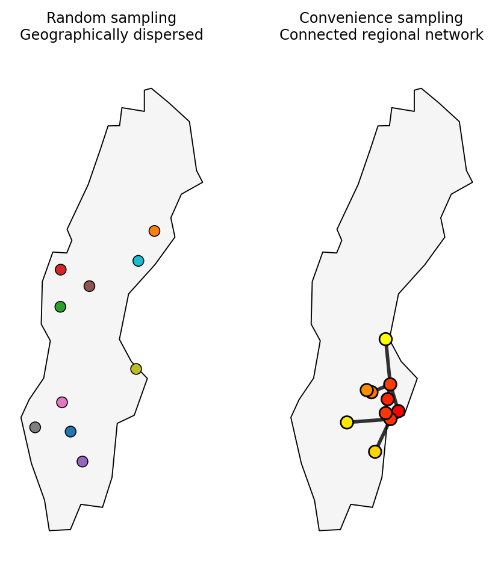

## Lecture-Lab 5

- **Module:** Data collection 2
- **Topic:** Attitudes vs. content features, NLP, implementing quantitative content analysis
- **Date:** 2026-09-15 at 11—17
- **Place:** MHM
- **Readings:** (Muijs 2011b, chs. 4 and 11; Johnson 2021, sec. 4.7)

## Individual Work 1

- **Module:** Data collection 2
- **Topic:** Implement a quantitative study (questionnaire or content) in [Google Forms](https://docs.google.com/forms/?authuser=0)
- **Date:** 2026-09-18 at 09—12
- **Place:** Zoom
- **Readings:**

## Lecture-Lab 6

- **Module:** Data analysis 2
- **Topic:** Multivariate analysis and regression analysis
- **Date:** 2026-09-22 at 11—17
- **Place:** MHM
- **Readings:** (Muijs 2011b, ch. 9; Djurfeldt and Barmark 2009; Björk et al. 2019; McPherson 2005)

## Lecture-Lab 7

- **Module:** Data analysis 2
- **Topic:** Interactions between variables, data transformations, GLM and logistic regression
- **Date:** 2026-09-25 at 09—12
- **Place:** Zoom
- **Readings:** (Muijs 2011b, ch. 12; Djurfeldt and Barmark 2009, ch. 10; McPherson and O’Neill 2010b)

## Individual Work 2

- **Module:** Data analysis 2
- **Topic:** Implement data transformations and MRA with [Google Colab](https://colab.research.google.com/)
- **Date:** 2026-10-02 at 09—12
- **Place:** Zoom
- **Readings:**

## Examination 2

- **Module:** Examination assignment 2
- **Topic:** Literature review paper and opposition
- **Date:** 2026-10-20 at 10—16
- **Place:** MHM
- **Readings:**

## Lecture-Labs and readings

Lecture-Lab

Module and topic

Readings

**Lecture-Lab 1**

**Data collection 1:** Research design, theoretical models, test scores, implementing variables

(Muijs 2011b, chs. 1 and 3–4; Ehninger et al. 2021)

**Lecture-Lab 2**

(Muijs 2011b, chs. 5–6; Field 2017; Johnson 2021)

**Lecture-Lab 3**

**Data analysis 1:** Inferential analysis, bivariate analysis and hypothesis testing with [Jamovi](https://www.jamovi.org/download.html)

(Muijs 2011b, chs. 7–8 and 10; Krupp-Schleußner and Lehmann-Wermser 2018)

**Lecture-Lab 4**

(Muijs 2011b, chs. 2 and 8; Djurfeldt et al. 2018; McPherson and O’Neill 2010b, 2010a)

**Lecture-Lab 5**

**Data collection 2:** Attitudes vs. content features, NLP, implementing quantitative content analysis

(Muijs 2011b, chs. 4 and 11; Johnson 2021, sec. 4.7)

**Lecture-Lab 6**

**Data analysis 2:** Multivariate analysis and regression analysis

(Muijs 2011b, ch. 9; Djurfeldt and Barmark 2009; Björk et al. 2019; McPherson 2005)

**Lecture-Lab 7**

**Data analysis 2:** Interactions between variables, data transformations, GLM and logistic regression

(Muijs 2011b, ch. 12; Djurfeldt and Barmark 2009, ch. 10; McPherson and O’Neill 2010b)

## AI use in academic work

- OK: brainstorm ideas, do research
- OK: generate project materials
- OK: data analysis, statistics tools
- OK: be transparent with your prompts
- Not OK: copy-paste text to your exam
- Not OK: generate fake empirical data
- Not OK: upload content you dont own
- Not OK: upload data with personal info
- https://gemini.google.com/

## Lecture-Lab 1.1: Research design and theoretical models

KNHSM08 / KOMP014: Quantitative Methods in  
Music Education Research 2026

nils.holmberg@iko.lu.se

## The IMRD structure

Intro

Methods

Results

Discussion

## Foundations of Quantitative Research

- **Definition**: Explains phenomena using numerical data and mathematical analysis.
- **Post-Positivism**: Objective reality exists, but researchers can only approximate it.
- **Pragmatism**: Choose fit-for-purpose methods based on what works.
- **Research Paradigm**: Test a model of instrument practice through structured surveys.
- **Data Conversion**: Convert subjective beliefs into analysable numerical data.

Intro

Methods

Results

Discussion

## Formulating Research Objectives

- **First Step**: Define realistic, researchable objectives before choosing tools.
- **Research Question**: What predicts students’ intention to practise an instrument?
- **Inferential Focus**: Explain why and how factors relate, beyond description.
- **Theory-Driven**: Test relationships derived from the Theory of Planned Behavior.
- **Scope Restriction**: Predict intentions without measuring every external factor.

Intro

Methods

Results

Discussion

## Observational Survey Design

- **Survey Research**: Efficiently collects extensive real-world relational data.
- **Cross-Sectional**: Survey students once to examine current intentions and predictors.
- **Non-Experimental**: Measure beliefs and attitudes without manipulating them.
- **Design Priority**: Valid measurement matters more than sophisticated analysis.
- **Application**: Capture attitudes, peer norms, and perceived control by questionnaire.

Intro

Methods

Results

Discussion

## Defining the Target Population & Sample

- **Units/Cases**: The students from whom data are collected.
- **Population**: The wider group to which findings should generalise.
- **Generalisability**: Sample findings require control of bias to generalise.
- **Sampling Goal**: Obtain a representative, unbiased student sample.
- **Nested Context**: Students cluster within classes and schools.

Intro

Methods

Results

Discussion

## The Theoretical Model

- **Hypothesis**: A tentative, testable explanation accepted or rejected provisionally.
- **Attitude**: A student’s evaluation of practising their instrument.
- **Subjective Norm**: Perceived pressure from parents, teachers, and peers.
- **Perceived Control**: Perceived ease or difficulty of practising.
- **Formulated Hypothesis**: Attitudes, norms, and control predict practice intentions.

Intro

Methods

Results

Discussion

## Theory of Planned Behavior

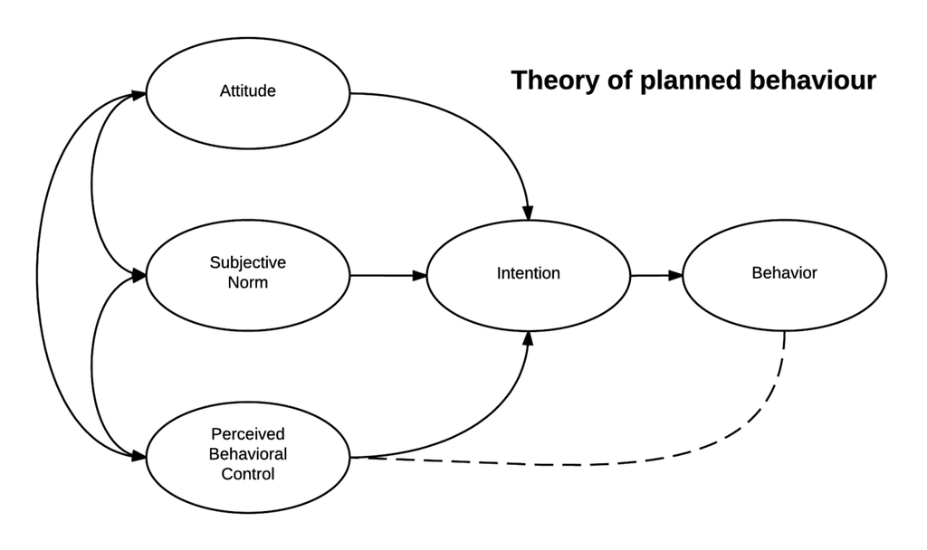

- https://en.wikipedia.org/wiki/Theory_of_planned_behavior

## Dependent and Independent Variables

- **Variable**: A student characteristic that varies between individuals.
- **Dependent Variable**: The outcome: *intention to practise*.
- **Independent Variables**: Predictors: *attitude*, *subjective norm*, and *perceived control*.
- **Causal Premise**: Predictor changes are associated with changes in intention.
- **Confounding Control**: Measure factors such as age and instrument type.

Intro

Methods

Results

Discussion

## Measurement: Latent vs. Manifest Variables

- **Latent Variables**: Abstract concepts that cannot be observed directly.
- **Indirect Measurement**: Use questionnaires to measure internal mental states.
- **Manifest Variables**: Observable survey items representing latent concepts.
- **Construct Structure**: Represent each latent variable with multiple items.
- **Theory Role**: Ground mappings between items and factors in theory.

Intro

Methods

Results

Discussion

## Variable Operationalization & Survey Writing

- **Operationalization**: Convert attitudes and intentions into numerical data.
- **Rating Scales**: Use closed Likert scales from strong disagreement to agreement.
- **Writing Items**: Draft concrete statements representing each construct.
- **Using Scales**: Multiple items reduce response error and improve measurement.
- **Survey Structure**: Put demographics last to reduce initial frustration.

Intro

Methods

Results

Discussion

## Levels of Measurement

- **Significance**: Measurement levels determine valid meanings and statistical tests.
- **Nominal Level**: Unordered categories, such as gender or instrument type.
- **Ordinal Level**: Ordered categories with unequal distances, such as Likert items.
- **Continuous Level**: Numbers with equal intervals, such as age in months.
- **Scale Calculation**: Combine ordinal items into continuous scale scores.

Intro

Methods

Results

Discussion

## Measurement Quality: Validity and Reliability

- **The Golden Rule**: Sophisticated analysis cannot rescue poor measurement.
- **Validity (Accuracy)**: An instrument measures its intended concept.
- **Validating TPB**: Review literature and pilot items with teachers and students.
- **Reliability (Consistency)**: Measurement is stable and free from random error.
- **Internal Consistency**: Use Cronbach’s alpha to assess each TPB scale.

Intro

Methods

Results

Discussion

Lab 1.1:  
Research design and theoretical models

## Lab 1.1: Research Design

| Design Dimension | Guiding Research Question | What it Clarifies |
| --- | --- | --- |
| Unit of analysis | What are we studying? | The object of inquiry (individuals, texts, organizations, interactions, etc.) |
| Method | How do we study it? | Data collection and analysis techniques |
| Epistemology | What do we believe knowledge is? | What counts as valid knowledge and truth |
| Logic of reasoning | How do we connect theory and data? | Deduction, induction, abduction |
| Type of inference / claim | What kind of claim do we want to make? | Description, explanation, interpretation, causality, generalization |

## Lab 1.1: Research questions

```python
# A. Formulera en preliminär forskningsfråga med kvalitativ design!
# RQ:

# 1. Vad studerar vi?
# Svar:

# 2. Hur studerar vi det?
# Svar:

# 3. Vad menar vi med kunskap?
# Svar:

# 4. Hur kopplar vi teori och data?
# Svar:

# 5. Vilken typ av anspråk vill vi göra?
# Svar:
```

```python
# B. Omformulera forskningsfrågan till att besvaras med kvantitativ design!
# RQ:

# 1. Analysenhet
# Det objekt vi undersöker (individer, texter, organisationer, interaktioner etc.)

# 2. Metod
# Hur vi samlar in och analyserar data.

# 3. Epistemologi
# Vad som räknas som giltig kunskap och sanning.

# 4. Resonemangslogik
# Hur vi rör oss mellan teori och data (deduktion, induktion, abduktion).

# 5. Typ av inferens/anspråk
# Vilken typ av slutsats vi vill dra (beskrivning, förklaring, tolkning, kausalitet, generalisering).
```

- https://gemini.google.com/

## Lab 1.1: Research proposal

1. Problem & research question
2. Theory & previous research
3. Research design & data collection
4. Data analysis plan
5. Expected contribution & timeline

# Lecture-Lab 1.2: Survey construction and data collection

KNHSM08 / KOMP014: Quantitative Methods in  
Music Education Research 2026

nils.holmberg@iko.lu.se

## Ethical TPB Surveys & Informed Consent

- **Informed Consent**: Obtain parental and student consent before surveying school musicians.
- **Anonymity Guarantee**: Protect anonymity to encourage honest reports of practice habits.
- **Voluntary Participation**: Students may decline or withdraw without penalty.
- **Clear Research Purpose**: Explain the study and how responses will be used.
- **Establishing Credibility**: Institutional credibility helps improve student response rates.

Intro

Methods

Results

Discussion

## Structuring the Musical Practice Questionnaire

- **Thematic Blocks**: Organize questions into clear, logical sections.
- **Outcome Section**: Begin with intention to practise, the dependent variable.
- **Theoretical Predictors**: Separate attitudes, subjective norms, and perceived control.
- **Covariates Section**: Group lesson history, instrument family, and grade level.
- **Demographics at the End**: Put sensitive questions last to reduce attrition.

Intro

Methods

Results

Discussion

## Formulating Good Items for Young Musicians

- **Clear and Simple Phrasing**: Match wording to students’ reading levels.
- **Avoid Double Negatives**: Remove negative phrasing that increases cognitive burden.
- **One Question Per Item**: Split statements that ask about two things.
- **Minimize Jargon**: Avoid technical, institutional, or culturally insensitive terms.
- **Instrument Piloting**: Test drafts with teachers and a small student sample.

Intro

Methods

Results

Discussion

## Latent Constructs: Dimensions & Indicators

- **Latent Variables**: TPB concepts cannot be observed directly.
- **Multidimensional Constructs**: Complex concepts may contain several dimensions.
- **Manifest Indicators**: Measure each dimension with survey items.
- **Error Cancellation**: Multiple indicators reduce individual response error.
- **Optimal Scale Length**: Use 4–10 items, balancing reliability and burden.

Intro

Methods

Results

Discussion

## Response Formats & Alternatives

- **Open-Ended Limitations**: Rich responses are time-consuming to code.
- **Closed-Ended Comparability**: Predefined choices enable straightforward statistical comparison.
- **Likert Scale Formats**: Rate agreement from strongly disagree to strongly agree.
- **Category Thresholds**: Use 3–7 options that students can distinguish.
- **Don’t Know Category**: Avoid forcing uninformed students toward neutral responses.

Intro

Methods

Results

Discussion

## Managing Response Biases in Music Research

- **Social Desirability Bias**: Students may exaggerate practice to please adults.
- **The Hawthorne Effect**: Being studied may temporarily change practice habits.
- **Positive Response Bias**: High ratings can obscure genuine practice priorities.
- **Central Tendency Problem**: Students may avoid commitment by choosing midpoints.
- **Evaluator Bias**: A researcher’s presence can systematically influence answers.

Intro

Methods

Results

Discussion

## Sampling Strategies & Sample Bias

- **Target Population**: The music students to whom findings should generalise.
- **Unbiased Representation**: Representative samples support population-level conclusions.
- **Simple Random Sampling**: Give every student an equal selection chance.
- **Stratified & Quota Sampling**: Ensure rare subgroups are represented.
- **Cluster & Multistage Sampling**: Select schools, then nested classrooms or students.

Intro

Methods

Results

Discussion

## Online, Paper, and Telephone Surveys

- **Pencil-and-Paper Surveys**: Familiar and self-paced, but require manual entry.
- **Online Survey Efficiency**: Direct database capture prevents transcription errors.
- **Access Gaps**: Unequal internet access can bias online samples.
- **Telephone Surveys**: Help fill quotas but often face non-response.
- **Maximizing Response Rates**: Use short surveys, incentives, and timely reminders.

Intro

Methods

Results

Discussion

## Data Screening & Missing Values in SPSS

- **Source of Missingness**: Skipped items, invalid codes, and dropout create missing data.
- **Loss of Power**: Missing responses reduce sample size and statistical power.
- **SPSS Output Interpretation**: “Valid Percent” excludes missing cases.
- **Dedicated Missing Codes**: Assign distinct codes such as 99 or 999.
- **Avoid Value Overlap**: Keep missing codes outside every valid scale range.

Intro

Methods

Results

Discussion

## Index Variables & Recoding TPB Scales

- **Recoding Variables**: Reverse negative items so all scores align.
- **Creating Index Variables**: Sum or average items into continuous TPB scales.
- **Data Transformations**: Convert practice hours into categories using cutoffs.
- **Dummy Variables**: Recode nominal predictors into binary indicators.
- **Internal Consistency**: Check Cronbach’s alpha before calculating scale indexes.

Intro

Methods

Results

Discussion

Lab 1.2:  
Survey construction and data collection

## Lab 1.2: Theoretical model

- Download sample [dataset](https://github.com/cca-cce/osm-comm/raw/refs/heads/main/csv/penguins.tsv) and analyze model
- Perform descriptive statistics and data transformations
- `Perform bivariate analyses and hypothesis testing`
- Perform multivariate analysis, multiple regression

```
graph LR
    direction LR

    subgraph Analysis [Factors expected to influence co-workers <br/>perceived access to information]
        direction LR

        %% Independent Variables
        iv1(co-worker age)
        iv2(co-worker role)
        iv3(organization type)

        %% Dependent Variable
        dv1[[<b>co-worker <br/>perceived access <br/>to information</b>]]

        %% Connections
        iv1 --> dv1
        iv2 --> dv1
        iv3 --> dv1
    end

    %% Node Styling
    style Analysis fill:#f9f9f9,stroke:#ccc,stroke-dasharray: 5 5
    style iv1 fill:#ffffff,stroke:#333,color:#000
    style iv2 fill:#ffffff,stroke:#333,color:#000
    style iv3 fill:#ffffff,stroke:#333,color:#000
    style dv1 fill:#517699,stroke:#2b4156,color:#fff

    %% Darker Arrow Styling (Indices start at 0)
    linkStyle 0,1,2 stroke:#000,stroke-width:2px;
```

## Lab 1.2: Data collection plan

| Dimension | Description |
| --- | --- |
| 1. Theoretical foundation | Research question, theoretical framework, and hypotheses that guide what must be measured. |
| 2. Operationalization of variables | Translation of concepts into measurable variables; use of validated scales and multi-item constructs where appropriate. |
| 3. Population and sampling strategy | Definition of target population, sampling frame, recruitment method, and planned sample size. |
| 4. Measurement design and questionnaire construction | Question wording, response formats, survey structure, pilot testing, and flow logic. |
| 5. Data quality and fieldwork procedures | Attention checks, prevention of duplicate responses, ethical procedures, and administration mode. |

## Lab 1.2: Data analysis plan

| Dimension | Description |
| --- | --- |
| 1. Analytical strategy | Specification of research aims and overall statistical approach aligned with hypotheses. |
| 2. Descriptive statistics | Summary of distributions, central tendencies, dispersion, and visualization of key variables. |
| 3. Data transformations | Index construction, reverse coding, scale reliability checks, recoding, and preparation for analysis. |
| 4. Bivariate analysis and hypothesis testing | Correlation analysis, mean comparisons, cross-tabulations, and initial hypothesis tests. |
| 5. Multivariate analysis and diagnosis | Regression or advanced modeling, inclusion of control variables, assumption checks, and model diagnostics. |

## Lab 1.2: Quantitative proposal

```python
# A. Develop point 1-5 to generate a data collection plan, including suggestions for survey questions and response alternatives using validated scales with references!

# 1. Theoretical foundation
#

# 2. Operationalization of variables
#

# 3. Population and sampling strategy
#

# 4. Measurement design and questionnaire construction
#

# 5. Data quality and fieldwork procedures
#
```

```python
# B. Develop point 1-5 to generate a data analysis plan!

# 1. Analytical strategy
#

# 2. Descriptive statistics
#

# 3. Data transformations
#

# 4. Bivariate analysis and hypothesis testing
#

# 5. Multivariate analysis and diagnosis
#
```

- https://gemini.google.com/

## Lab 1.2: Survey draft

| Variable | Suggested Survey Question (Swedish/English) | Validated Scale Reference |
| --- | --- | --- |
| Information Adequacy | Jag får den information jag behöver för att utföra mitt arbete effektivt. / I receive the info I need to do my job effectively. | Downs & Hazen (1977) (Communication Satisfaction Questionnaire) |
| Organizational Vision | Jag är väl informerad om organisationens övergripande mål och strategier. / I am well informed about the organization's goals. | De Ridder (2004) (Internal Communication Scale) |
| Feedback Quality | Min närmaste chef ger mig regelbunden information om min arbetsprestation. / My supervisor provides regular info on my performance. | Psychological Climate Questionnaire (Koys & DeCotiis, 1991) |
| Channel Accessibility | De digitala verktyg vi använder gör det lätt att hitta relevant information. / Digital tools make it easy to find relevant info. | TAM (Technology Acceptance Model) (Davis, 1989) |

## Lecture-Lab 1.3: Univariate and bivariate descriptive analyses

KNHSM08 / KOMP014: Quantitative Methods in  
Music Education Research 2026

nils.holmberg@iko.lu.se

## Descriptive Results & Univariate Analysis

- **Univariate Focus**: Examine each variable before studying relationships.
- **Data Screening**: Detect entry errors, invalid values, and missing data.
- **Level Constraints**: Measurement level determines appropriate descriptive statistics.
- **Variables Checklist**: Summarize backgrounds, TPB predictors, and practice intentions.
- **Initial Study Screen**: Count completed surveys and missing responses.

Intro

Methods

Results

Discussion

## Categorical Demographics & Frequency Analysis

- **Frequency Distribution**: Lists observed values and how often they occur.
- **Reporting Categorical Data**: Describe categories with counts and percentages.
- **SPSS Frequency Tables**: Use “Valid Percent” to exclude missing cases.
- **Cumulative Percent**: Shows the proportion at or below each ordered category.
- **Instrument Breakdown**: Report shares of strings, brass, woodwind, and percussion.

Intro

Methods

Results

Discussion

## Visualizing Discrete Categories: The Bar Plot

- **Categorical Visualization**: Use bar plots for nominal and ordinal frequencies.
- **Categorical X-Axis**: Displays categories or rating options.
- **Frequency Y-Axis**: Displays counts or percentages in each category.
- **Distribution Inspection**: Bar heights reveal dominant responses and skew.
- **Fun of Practice Item**: Plot one item to inspect agreement patterns.

Intro

Methods

Results

Discussion

## Continuous Scale Variables & Distributions

- **Continuous Latent Scales**: Treat standardized scores and index averages as continuous.
- **Distribution Shape**: Inspect how scores spread across their possible range.
- **The Bell Curve**: Normal distributions are symmetric around the center.
- **Positive and Negative Skew**: Scores cluster toward one end of the scale.
- **Practice Hours Distribution**: Check whether most students report few hours.

Intro

Methods

Results

Discussion

## Measures of Central Tendency

- **Summarizing Distributions**: Represent a variable with one typical score.
- **The Mode**: Most frequent value; suitable for nominal variables.
- **The Median**: Middle ranked score; suitable for ordinal data.
- **The Mean**: Sum of scores divided by the number of cases.
- **Outlier Sensitivity**: Prefer the median when extremes distort the mean.

Intro

Methods

Results

Discussion

## Measures of Spread and Dispersion

- **Concept of Spread**: Describes variation around the central value.
- **The Range**: Highest minus lowest score; sensitive to outliers.
- **Interquartile Range (IQR)**: Spread of the middle 50% of scores.
- **Standard Deviation (SD)**: Typical distance of scores from the mean.
- **SD Normal Rule**: About 68% lie within one SD of the mean.

Intro

Methods

Results

Discussion

## Descriptive Bivariate Comparison: Group Averages

- **Bivariate Comparison**: Compare groups on a continuous outcome.
- **Gender Skew Check**: Cross-tabulate gender across instrument sections.
- **SPSS Case Selection**: Select subgroups and calculate separate statistics.
- **Mean Comparison Table**: Compare average intentions between groups.
- **Subgroup Differences**: Identify instrument families with higher practice averages.

Intro

Methods

Results

Discussion

## Visualizing Group Differences: The Box Plot

- **Box Plot Utility**: Compare center and spread across groups.
- **The Median Line**: Marks each group’s 50th percentile.
- **The Box Dimensions**: Show the middle 50% of scores.
- **Whiskers**: Mark the range of typical, non-extreme values.
- **Outlier Identification**: Separate points flag unusually high or low cases.

Intro

Methods

Results

Discussion

## Pairwise Continuous Predictors and Outcome

- **Continuous Bivariate**: Examine two continuous variables together.
- **Positive Association**: Higher attitudes accompany stronger practice intentions.
- **Negative Association**: Greater barriers accompany weaker practice intentions.
- **Linear Relationships**: Predictor changes correspond to constant outcome changes.
- **Curvilinear Relationships**: Effects change strength or direction across values.

Intro

Methods

Results

Discussion

## Visualizing Scale Relationships: The Scatter Plot

- **Scatter Plot Design**: Plot each student as an X–Y point.
- **Horizontal X-Axis**: Displays the continuous predictor, such as Attitude.
- **Vertical Y-Axis**: Displays the continuous outcome, such as Intention.
- **Visualizing Density**: Clustering and slope show direction and strength.
- **Spotting Anomalies**: Isolated points reveal students outside the general trend.

Intro

Methods

Results

Discussion

## Next steps

- Lecture notes: https://cca-cce.github.io/osm-comm/web/edu/skoc42-lecture01.html

## References

Björk, Cecilia, Marja-Leena Juntunen, Jens Knigge, Bernd Pape, and Lars-Erik Malmberg. 2019. “Musikundervisning Förverkligas På Ojämlika Villkor i Årskurserna 1–6 i Finlands Svenskspråkiga Skolor.” *Finnish Journal of Music Education* 22: 30–58.

Djurfeldt, Göran, and Mimmi Barmark. 2009. *Statistisk Verktygslåda 2: Multivariat Analys*. Studentlitteratur. https://minprodukt2.studentlitteratur.se/dill/#/tematoc/33163_statistisk_verktygslada_2.

Djurfeldt, Göran, Rolf Larsson, and Ola Stjärnhagen. 2018. *Statistisk Verktygslåda 1: Samhällsvetenskaplig Orsaksanalys Med Kvantitativa Metoder*. 3rd ed. Studentlitteratur.

Ehninger, Julia, Jens Knigge, Michael Schurig, and Christian Rolle. 2021. “A New Measurement Instrument for Music-Related Argumentative Competence: The MARKO Competency Test and Competency Model.” *Frontiers in Education* 6: 668538. https://doi.org/10.3389/feduc.2021.668538.

Field, Andy. 2017. *Discovering Statistics Using IBM SPSS Statistics*. 5th ed. Sage. https://edge.sagepub.com/field5e.

Johnson, David. 2021. “Raising Voices: Singing Repertoire and Practices in Swedish Schools.” PhD thesis, Lund University. https://lucris.lub.lu.se/ws/portalfiles/portal/96905350/Raising_Voices.pdf.

Krupp-Schleußner, Valerie, and Andreas Lehmann-Wermser. 2018. “An Instrument for Every Child: A Study on Long-Term Effects of Extended Music Education in German Primary Schools.” *Music Education Research* 20 (1): 44–58. https://doi.org/10.1080/14613808.2016.1249361.

McPherson, Gary E. 2005. “From Child to Musician: Skill Development During the Beginning Stages of Learning an Instrument.” *Psychology of Music* 33 (1): 5–35. https://doi.org/10.1177/0305735605048012.

McPherson, Gary E., and Susan A. O’Neill. 2010a. *Student Questionnaire: Motivation to Study Music Compared to Other School Subjects*. Survey instrument, 38 items, 10 pp. https://doi.org/10.1177/1321103X10384202.

McPherson, Gary E., and Susan A. O’Neill. 2010b. “Students’ Motivation to Study Music as Compared to Other School Subjects: A Comparison of Eight Countries.” *Research Studies in Music Education* 32 (2): 101–37. https://doi.org/10.1177/1321103X10384202.

Muijs, Daniel. 2011a. *Data Set Accompanying Doing Quantitative Research in Education with SPSS*. SPSS system file, 889 cases and 61 variables. https://github.com/cca-cce/osm-comm/tree/main/csv/edu/komp014.

Muijs, Daniel. 2011b. *Doing Quantitative Research in Education with SPSS*. 2nd ed. Sage.